# Data Exploration mit Gapminder

# 3.5 Layer

Mehrere Layer auf denselben Daten: Punkte + Glättungslinie + Konfidenzband.

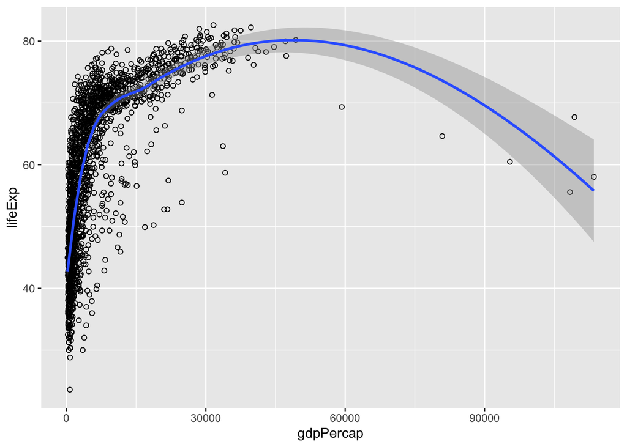

```r
ggplot(df, aes(x = gdpPercap, y = lifeExp)) +
  geom_point(shape = 1) +
  geom_smooth(method = "loess")
```

Wenn man `color` nur im geom_point setzt, bleibt die Glättung über alle Daten gemeinsam:

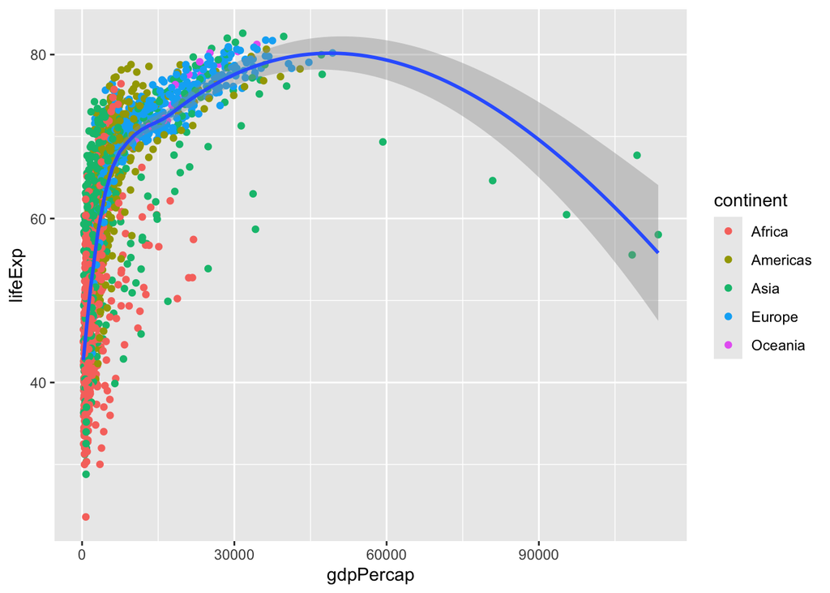

```r
ggplot(df, aes(x = gdpPercap, y = lifeExp)) +
  geom_point(aes(color = continent), shape = 19) +
  geom_smooth(method = "loess")
```

ggplot-Histogramm:

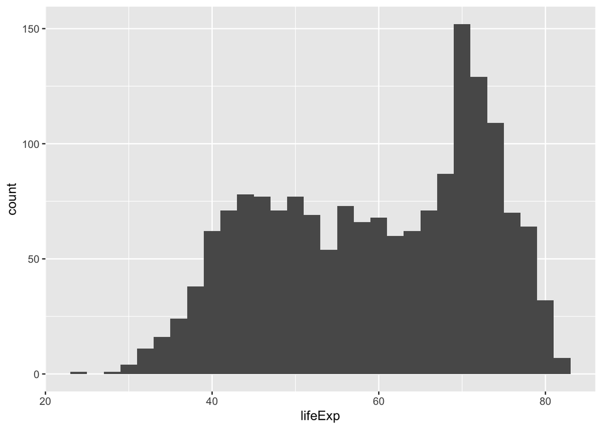

```r
ggplot(df, aes(x = lifeExp)) + geom_histogram(binwidth = 2)
```

Schrittweiser Aufbau mit `+`, so wie das `pb`-Beispiel im Buch. Find ich praktisch zum Ausprobieren, weil man nicht jedes Mal alles neu schreiben muss.

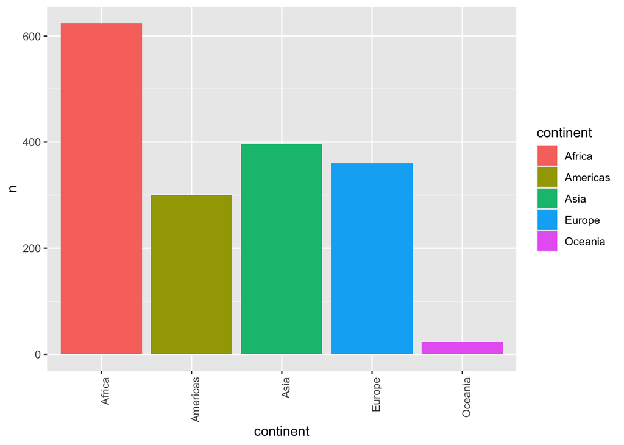

```r
pb <- ggplot(groups, aes(x = continent, y = n))
pb <- pb + geom_bar(stat = "identity")
pb <- pb + aes(fill = continent)
pb <- pb + theme(axis.text.x = element_text(angle = 90, hjust = 1))
pb
```

Und das Ganze in Polarkoordinaten, nur um es mal gesehen zu haben:

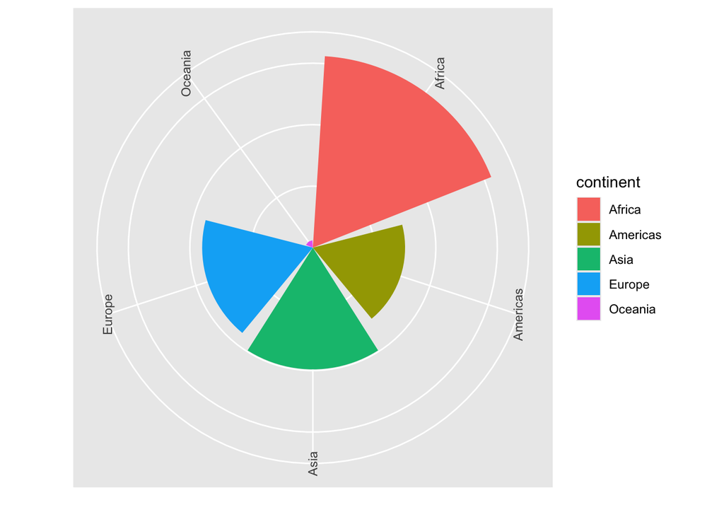

```r
pb + coord_polar() +
  theme(axis.text.y = element_blank(), axis.ticks = element_blank()) +
  xlab("") + ylab("")
```

# 3.6 Verteilungen in 1D

Im Buch ist die kategoriale Variable `gene` und der Wert `value`. Bei mir: `continent` und `lifeExp`.

Erstmal nur der Mittelwert als Balken – das ist genau die Variante, die das Buch als informationsarm bezeichnet, weil die ganze Verteilung verloren geht:

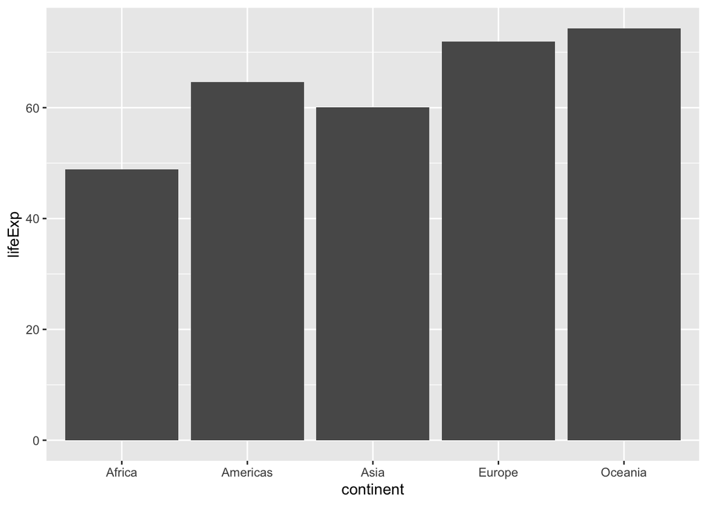

```r
ggplot(df, aes(x = continent, y = lifeExp)) +
  stat_summary(fun = mean, geom = "bar")
```

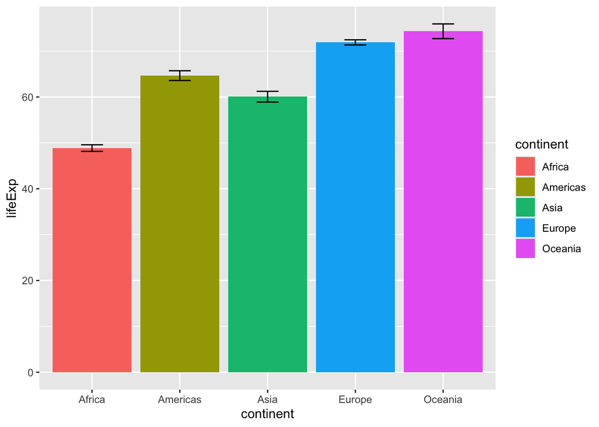

```r
library(Hmisc)
ggplot(df, aes(x = continent, y = lifeExp, fill = continent)) +
  stat_summary(fun = mean, geom = "bar") +
  stat_summary(fun.data = mean_cl_normal, geom = "errorbar", width = 0.25)
```

Boxplot sagt deutlich mehr (Median, Streuung, Schiefe):

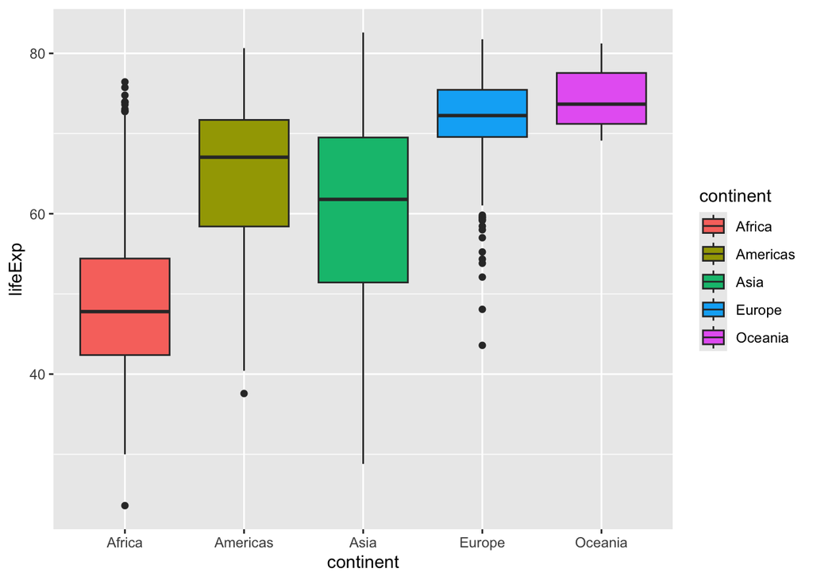

```r
p <- ggplot(df, aes(x = continent, y = lifeExp, fill = continent))
p + geom_boxplot()
```

Dotplot und Beeswarm zeigen die Einzelpunkte. Mit allen 1704 Zeilen wird das aber zu voll, deshalb nehm ich nur ein Jahr.

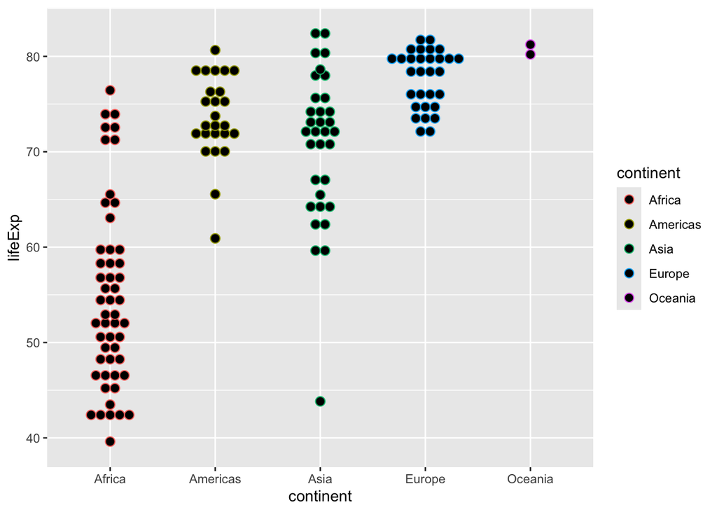

```r
df2007 <- subset(df, year == 2007)

ggplot(df2007, aes(x = continent, y = lifeExp)) +
  geom_dotplot(binaxis = "y", binwidth = 1, stackdir = "center",
               aes(color = continent))
```

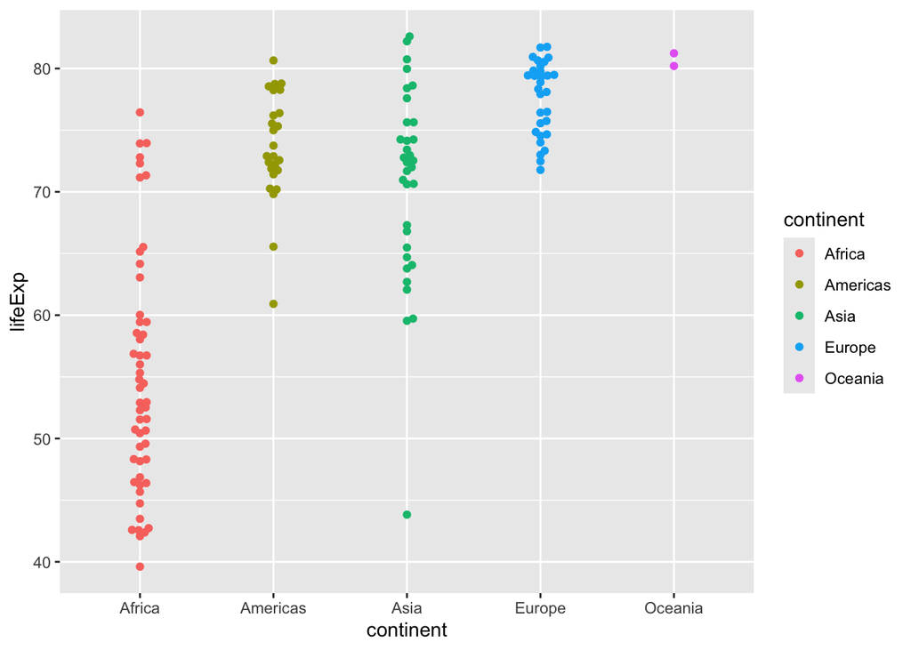

```r
library(ggbeeswarm)
ggplot(df2007, aes(x = continent, y = lifeExp, color = continent)) +
  geom_beeswarm()
```

Dichtekurven:

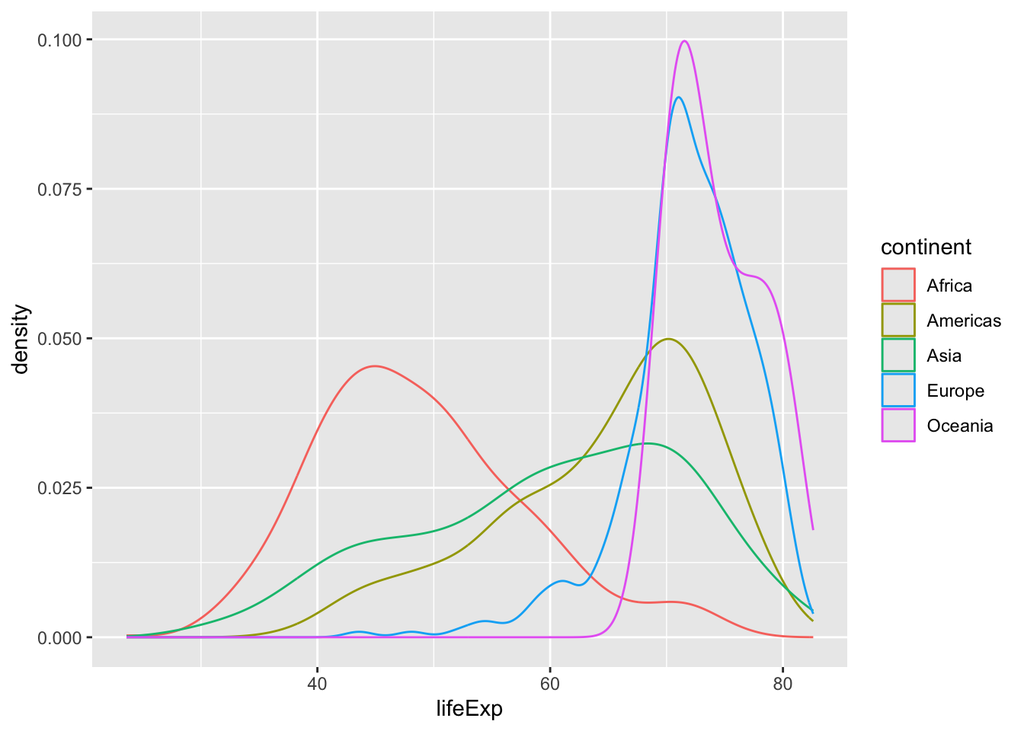

```r
ggplot(df, aes(x = lifeExp, color = continent)) + geom_density()
```

Violinplots (Dichte gespiegelt):

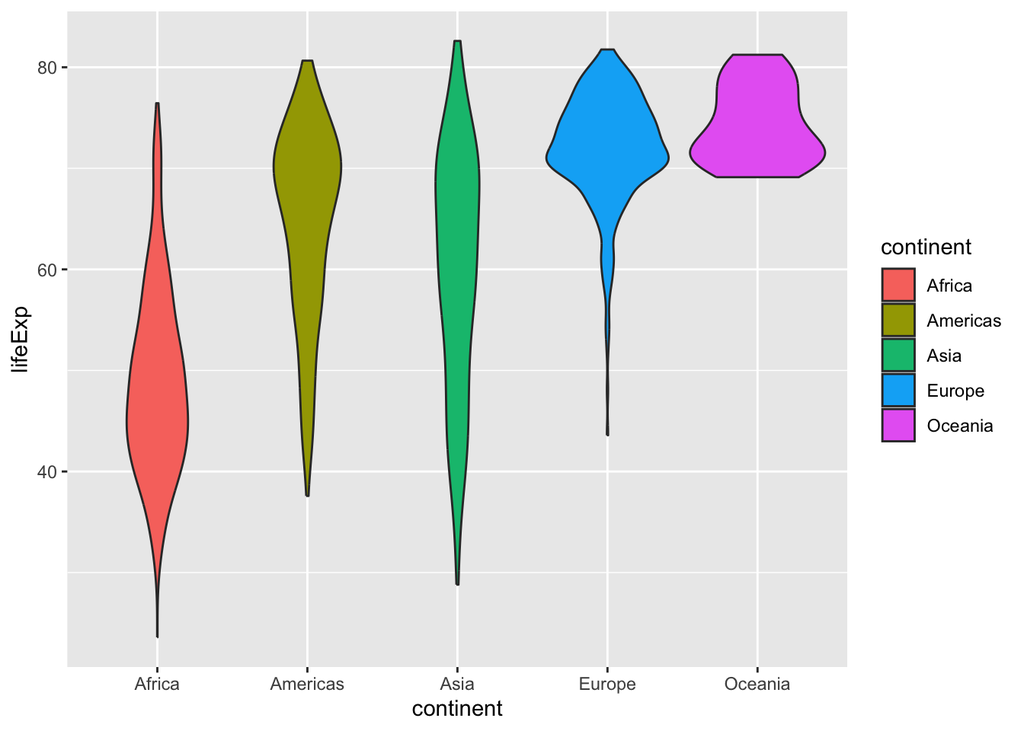

```r
p + geom_violin()
```

Ridgeline – versetzte Dichten, gut wenn es viele Gruppen sind:

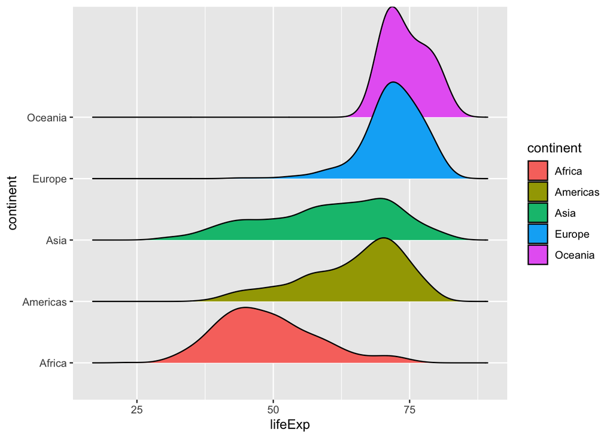

```r
library(ggridges)
ggplot(df, aes(x = lifeExp, y = continent, fill = continent)) +
  geom_density_ridges()
```

ECDF. Mag ich, weil kein Glättungsfenster nötig ist und nichts an Info verloren geht:

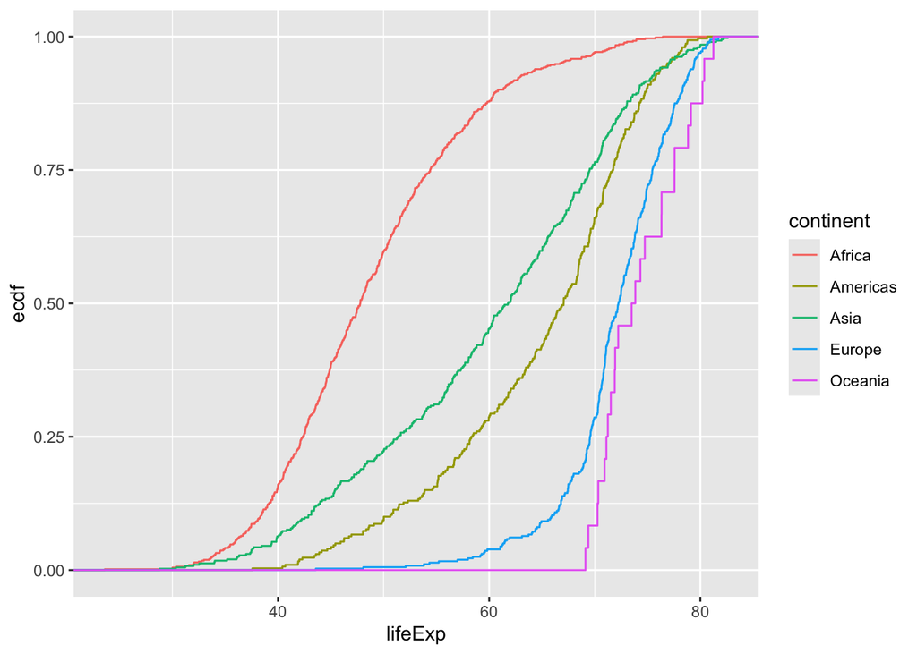

```r
ggplot(df, aes(x = lifeExp, color = continent)) + stat_ecdf()
```

Effekt einer Transformation (3.6.8): `gdpPercap` ist extrem rechtsschief, mit log10 sieht man die Verteilung erst richtig.

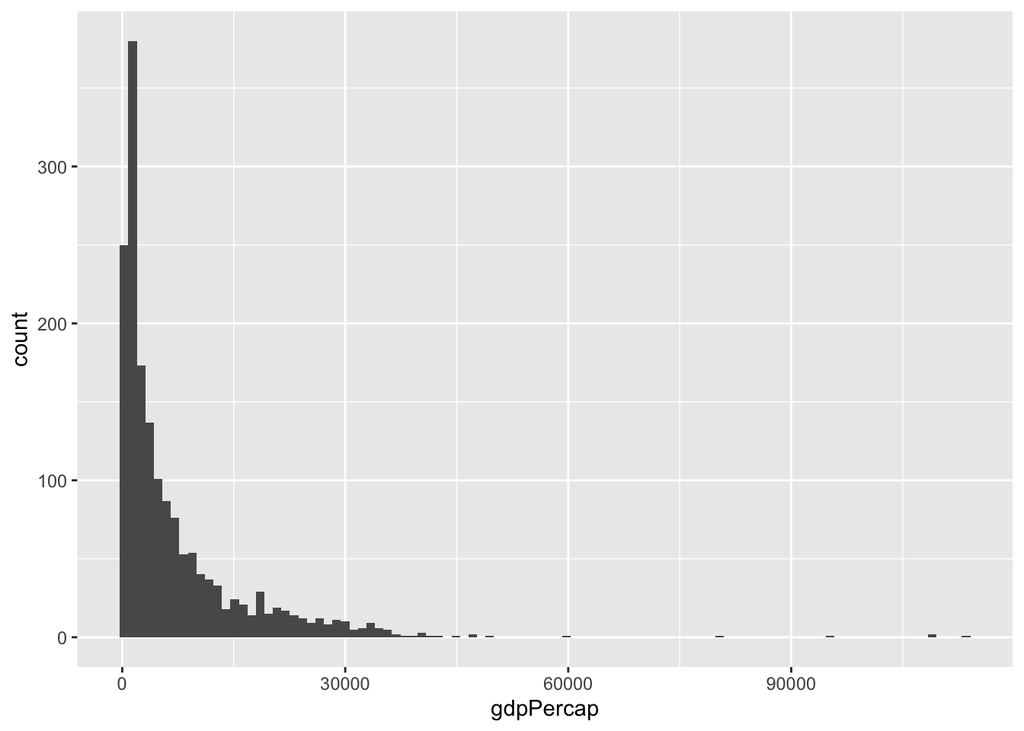

```r
ggplot(df, aes(x = gdpPercap)) + geom_histogram(bins = 100)
```

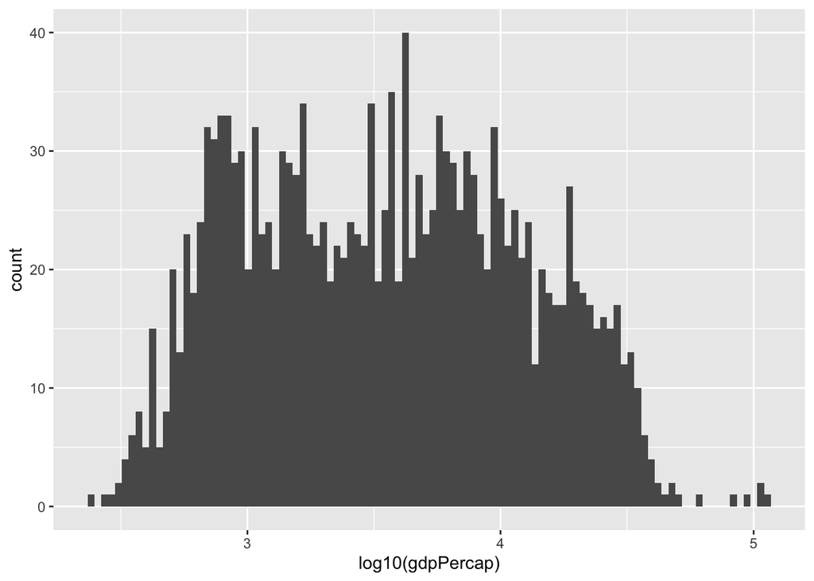

```r
ggplot(df, aes(x = log10(gdpPercap))) + geom_histogram(bins = 100)
```